# Environmental and LTL Indicators

Trend lines are shown when slope is significantly different from 0 at the p < 0.05 level. An orange line signifies an overall positive trend, and purple signifies a negative trend. Note that in the final report we will only test for trend when N >= 30. However, I have relaxed that requirement for the purposes of this document so that trends are highlighted when N >= 20. **This means that some trends shown here will not be present in the final document**. Dashed lines represent mean values of time series unless the indicator is an anomaly, in which case the dashed line is equal to 0. Shaded regions indicate the past ten years. If there are no new data for 2018, the shaded region will still cover this time period.

## Mid-Atlantic Bight

### Ocean Temperature

#### SST

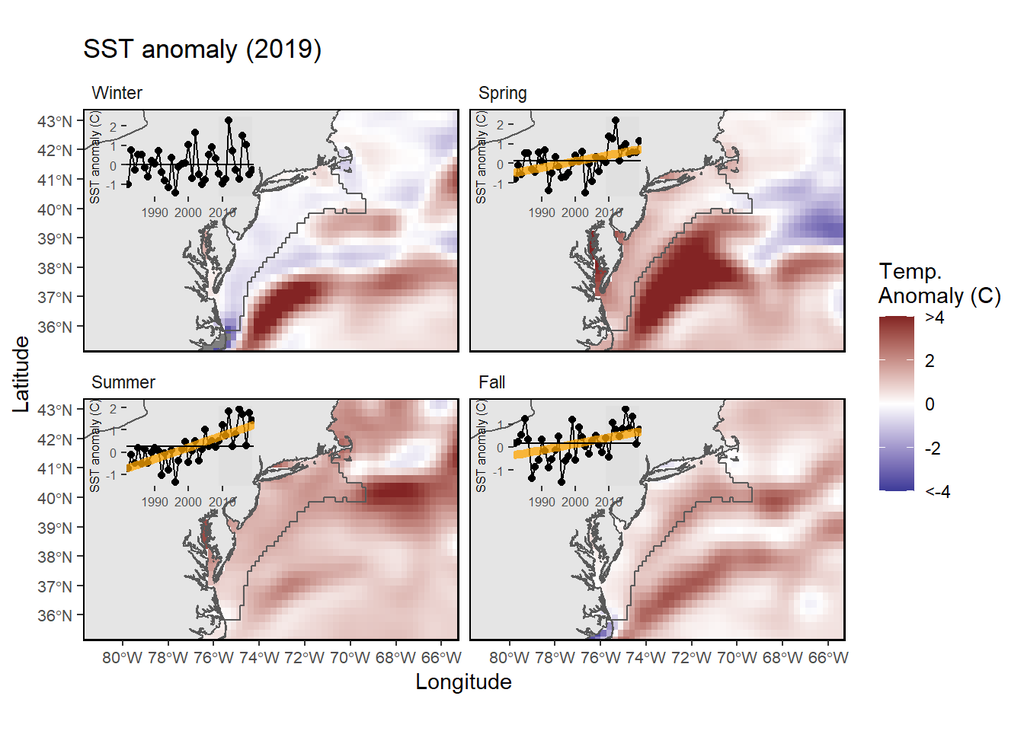

MAB seasonal sea surface temperature time series overlaid onto 2019 seasonal spatial anomalies.

#### Bottom temperature

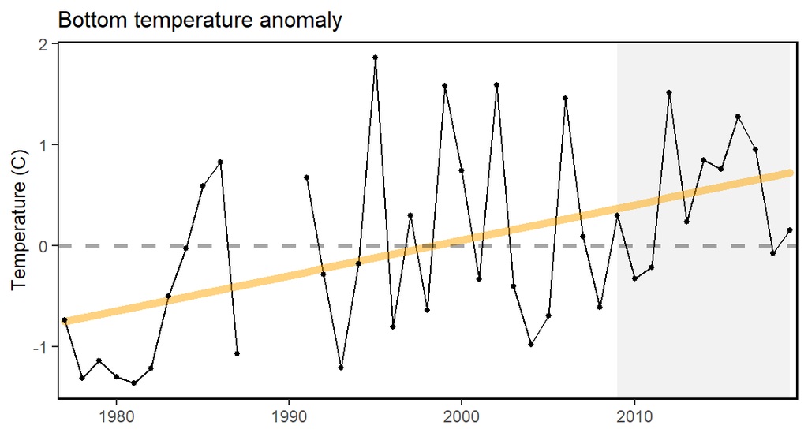

Annual bottom temperature in the Mid-Atlantic Bight.

### Chlorophyll and Primary Productivity

#### Primary production

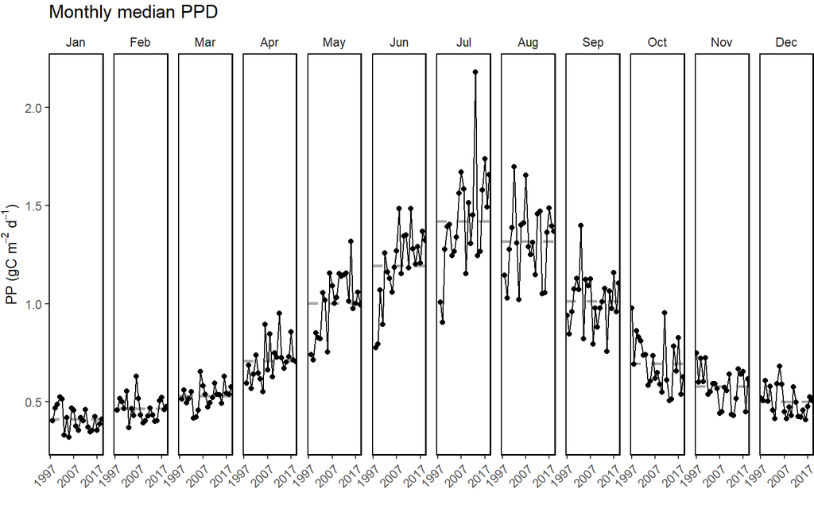

Monthly primary production trends show the annual cycle (i.e. the peak during the summer months) and the changes over time for each month.

#### Sesonal chlorophyll *a* & primary production

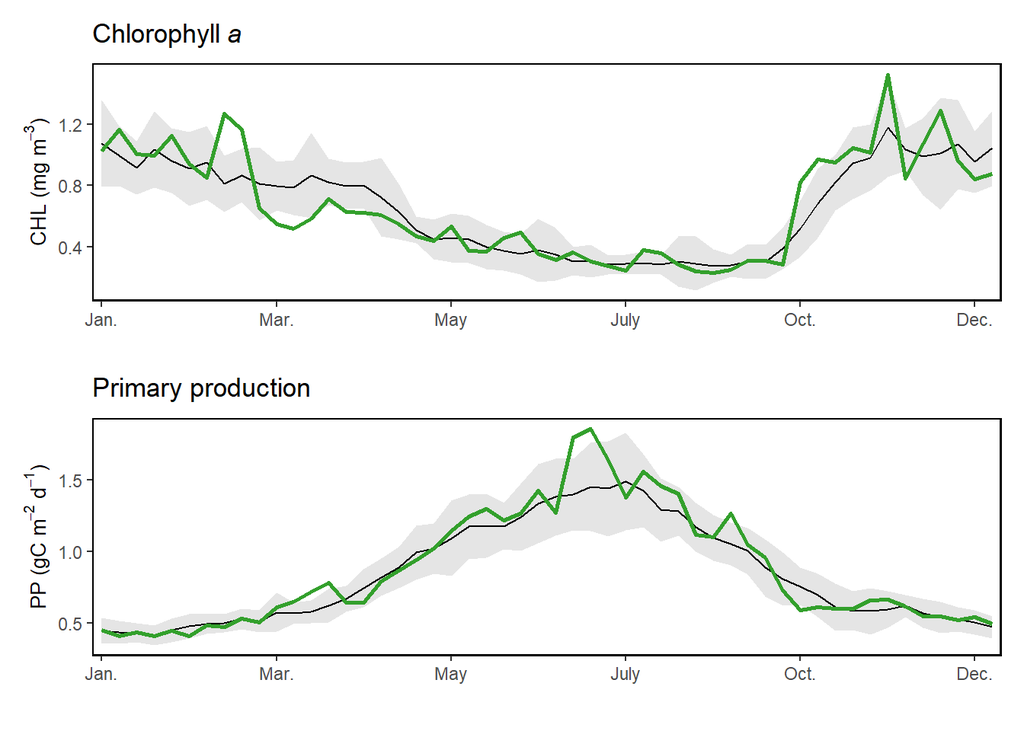

Weekly chlorophyll concentrations and primary productivity in the Mid-Atlantic are shown for by the colored line for 2019. The long-term mean is shown in black and shading indicates +/- 1 sample SD.

### Chesapeake Bay Water Quality Attainment

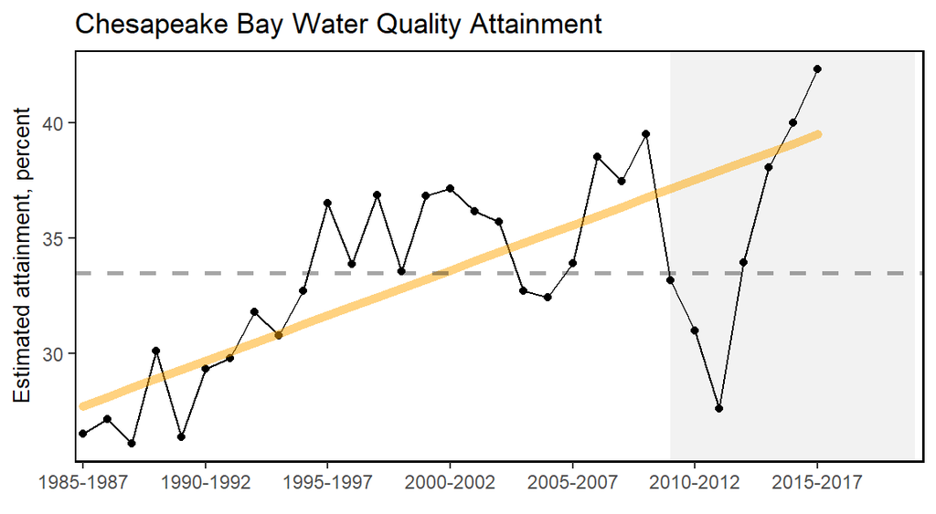

Water quality attainment in Chesapeake Bay following rolling three year assessment periods.

### Chesepeake Bay Salinity Anomolies

Write up on anomalies in salinity we saw in 2018,2019 following record breaking rain in 2018. The low salinities impacted [hypoxia, fish and oysters](https://docs.google.com/document/d/19ikLWKQWiRSrjmQJ2F7EB_ZcieBMk6Ykf1RX_Gissao/edit).

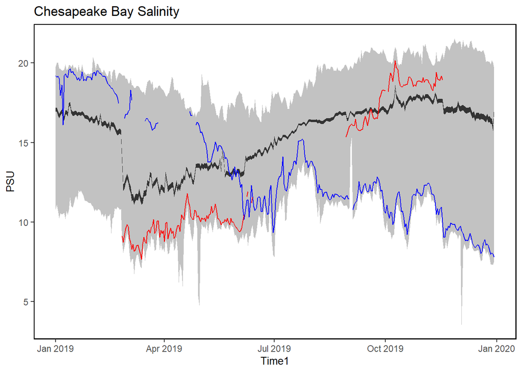

Salinity in Chesapeake Bay throughout 2018 (blue) and 2019 (red) as well as the daily average 2008-2019 (black).

### Zooplankton

#### Euphausiids + Cnidarians

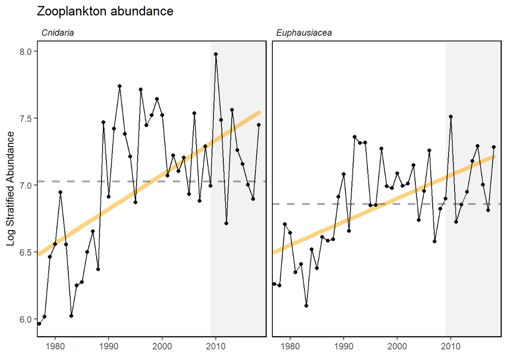

Stratified abundance of cnidarians and euphausiids in Mid-Atlantic Bight.

#### Small and Large Calanoid stratified abundance

#### Abundance anomaly

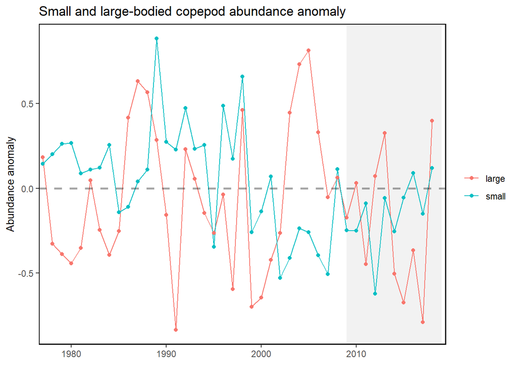

Large (red) and small-bodied (blue) copepod abundance in the Mid-Atlantic Bight.

#### Zooplankton Diversity

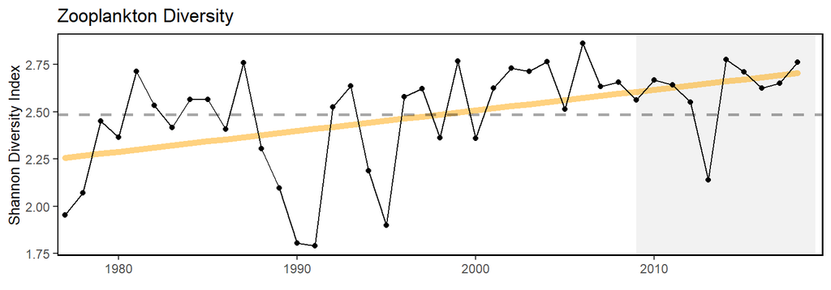

Zooplankton diversity in the Mid-Atlantic Bight.

### Cold Pool Index

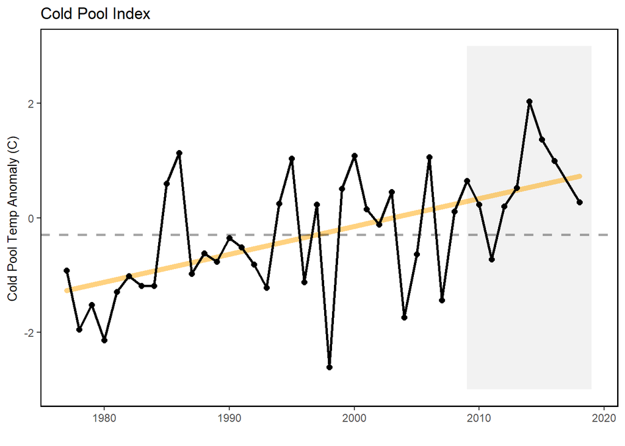

Cold pool index - mean bottom temperature anomaly for Sept-Oct in the MAB.

### Marine Heat Wave

[Notes](https://docs.google.com/document/d/0B1lP7X3GP_hQLTlmU3hqLUMzVWcwS2U5R2oxTWNWb19tcmFz/edit)

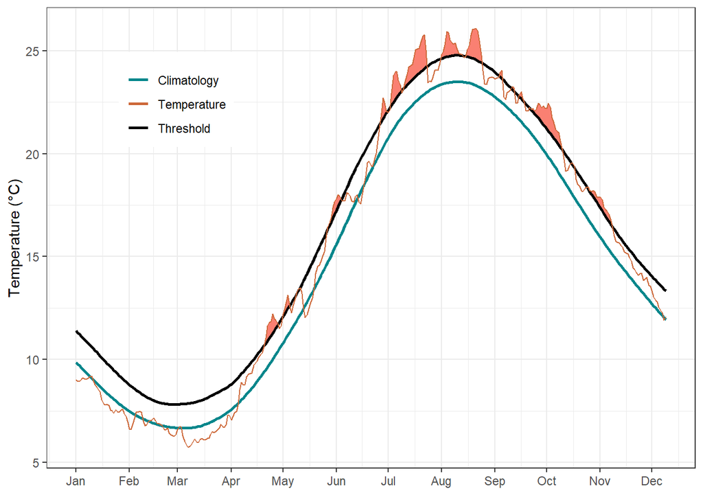

Marine heatwave events (red) in the Mid-Atlantic occuring in 2019.

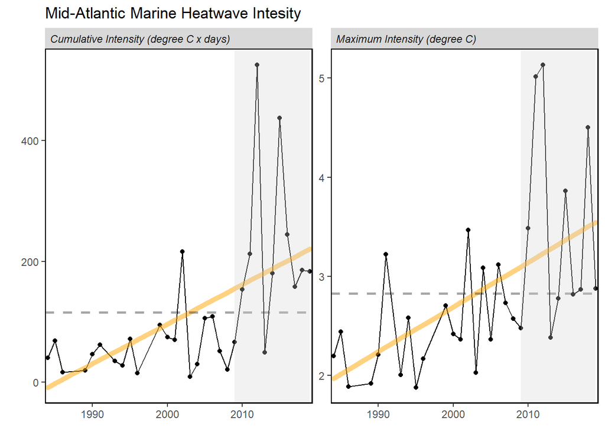

Marine heatwave cumulative intesity (left) and maximum intensity (right) in the Mid-Atlantic Bight.

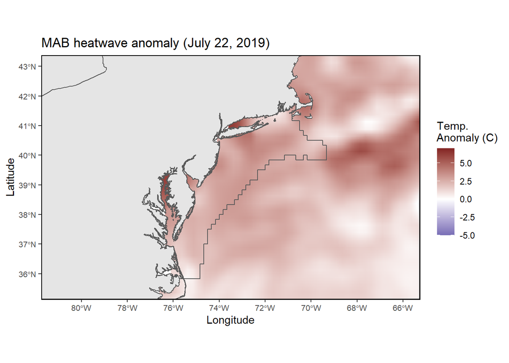

Maximum intensity heatwave anomaly in the Mid-Atlantic Bight occuring on July 22, 2019.

## Gulf of Maine & Georges Bank

### Ocean Temperature

#### SST

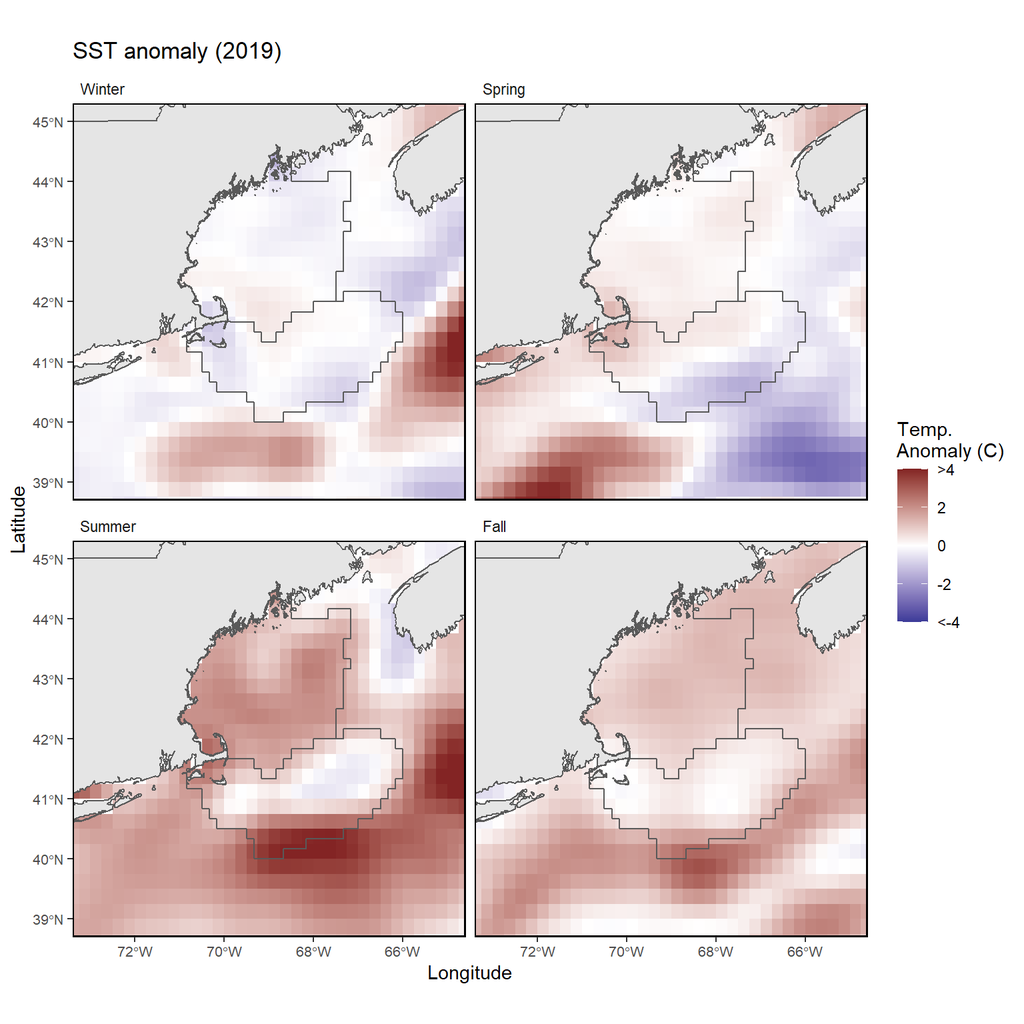

GB and GOM 2019 seasonal sea surface temperature spatial anomalies.

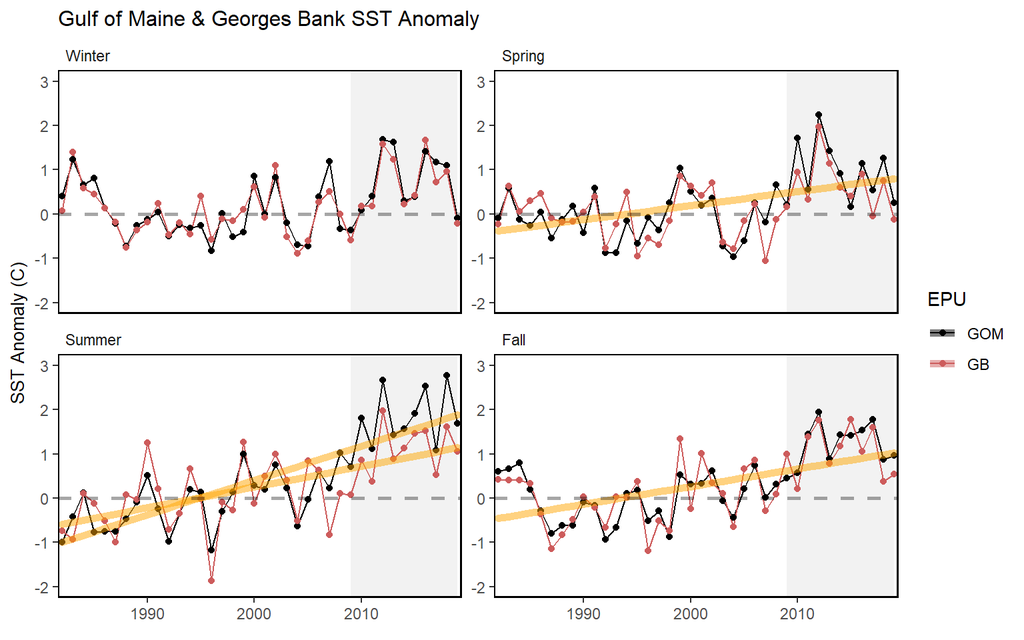

GB and GOM seasonal sea surface temperature anomaly time series.

#### Bottom temperature

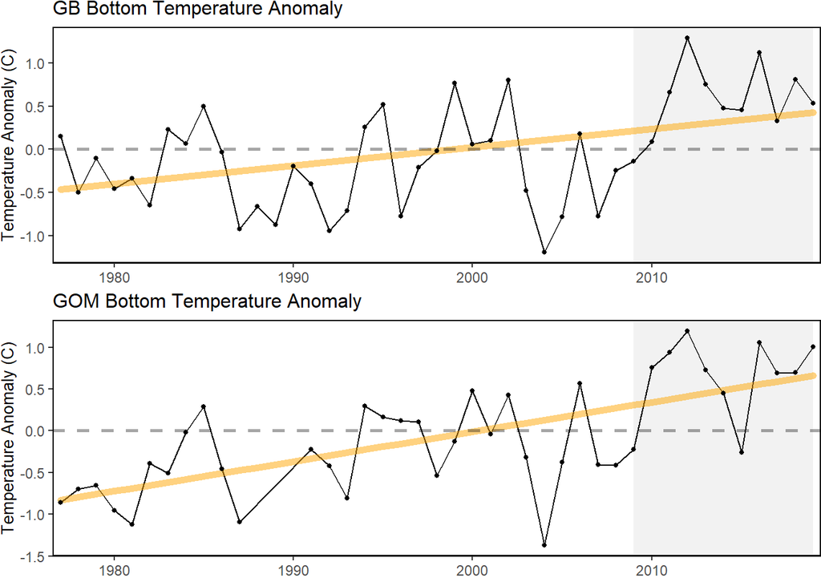

GB and GOM annual bottom temperature anomalies.

#### GOM Slopewater Proportions

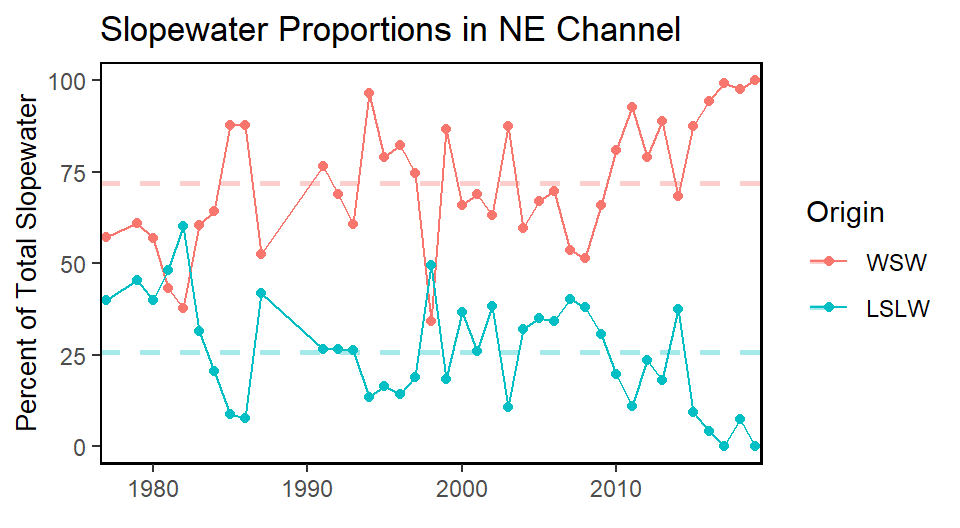

Proportion of warm slope water (WSW) and Labrador slope water (LSLW) entering the Gulf of Maine through the Northeast Channel.

### Chlorophyll and Primary Productivity

#### Primary production

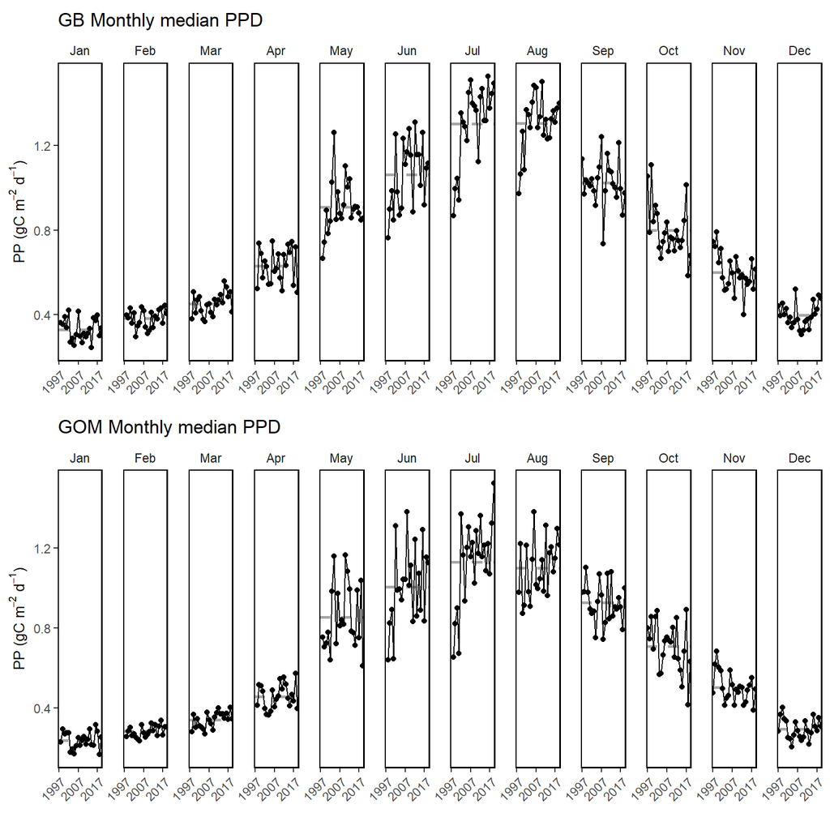

Monthly primary production trends show the annual cycle (i.e. the peak during the summer months) and the changes over time for each month.

#### Sesonal chlorophyll *a* & primary production

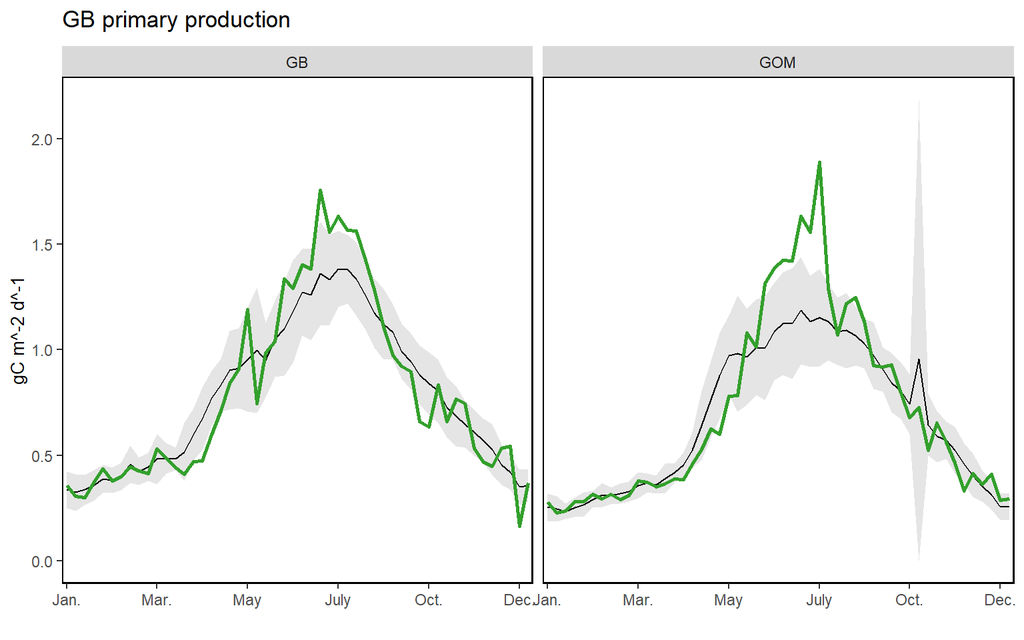

Weekly chlorophyll concentrations and primary productivity for 2019 in Georges Bank and Gulf of Maine are shown by the colored lines in the above figures. The long-term mean is shown in black and shading indicates +/- 1 sample SD.

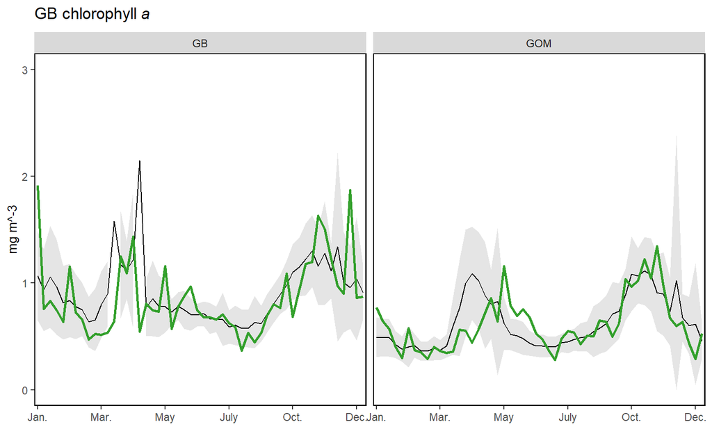

Weekly chlorophyll concentrations and primary productivity for 2019 in Georges Bank and Gulf of Maine are shown by the colored lines in the above figures. The long-term mean is shown in black and shading indicates +/- 1 sample SD.

### Zooplankton

#### Euphausiids + Cnidarians

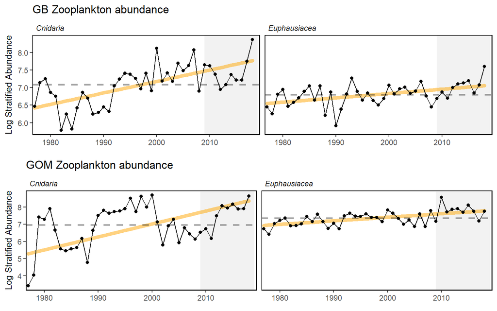

#### Small and Large Calanoid stratified abundance

#### Abundance anomaly

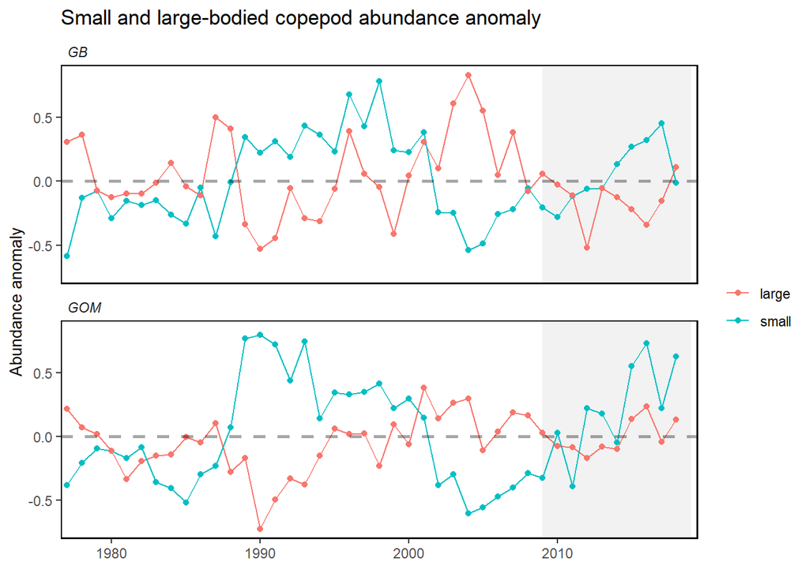

Large (red) and small-bodied (blue) copepod zooplankton abundance in New England.

#### PP anomaly

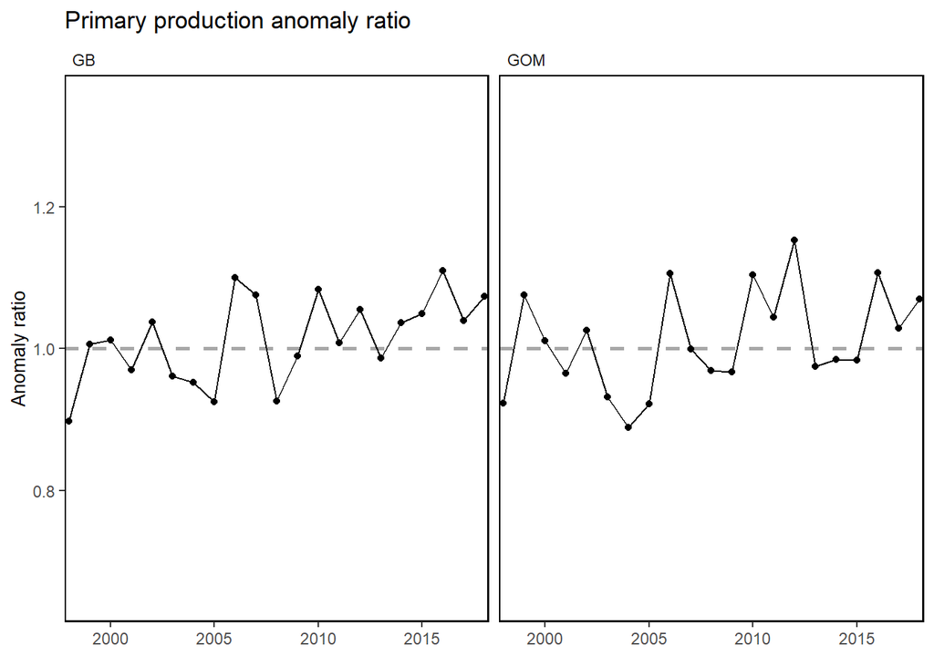

#### Zooplankton Diversity

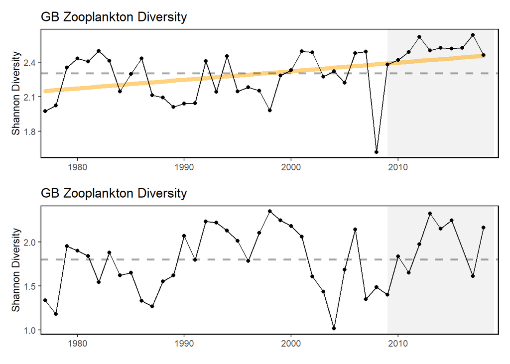

Zooplankton diversity in Georges Bank and Gulf of Maine.

### Marine Heat Wave

#### Monthly time series

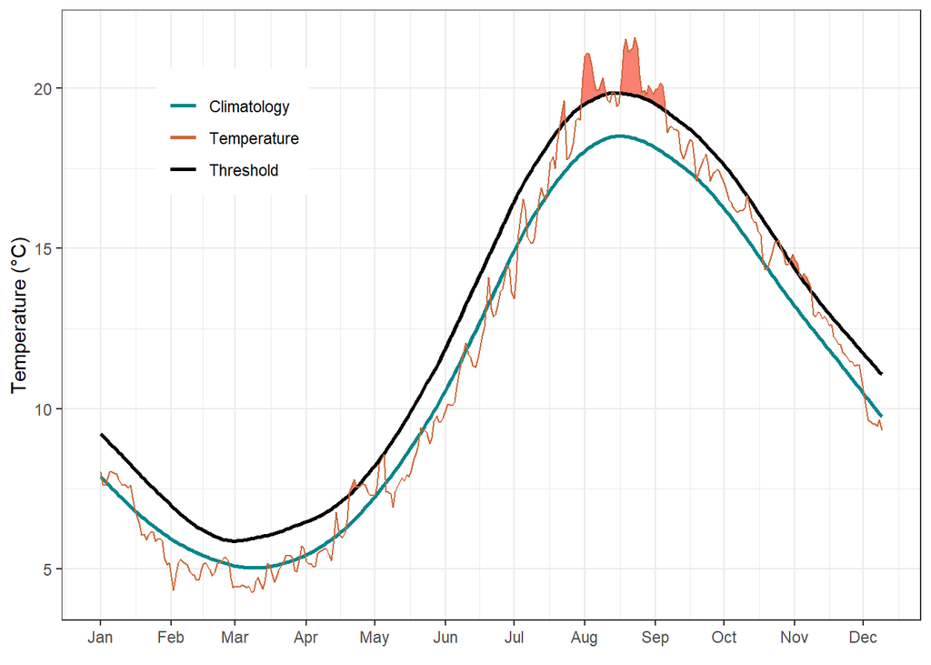

Georges Bank

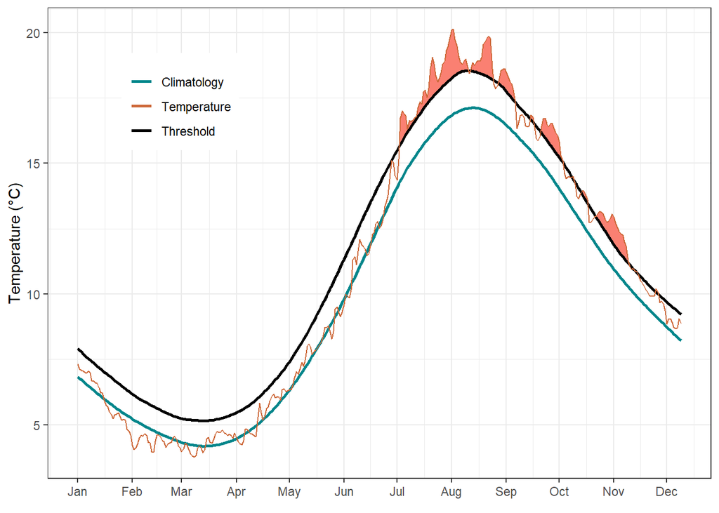

Gulf of Maine

#### Yearly timeseries

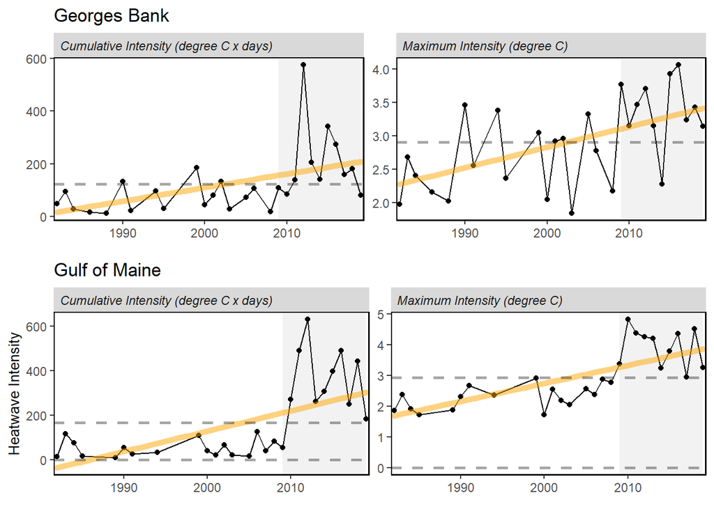

Marine heatwave cumulative intesity (left) and maximum intensity (right) in the Georges Bank and Gulf of Maine .

#### Maps

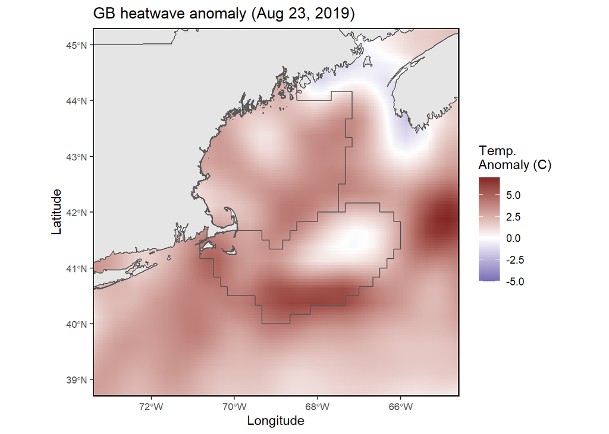

Maximum intensity heatwave anomaly in Georges Bank occuring on August 23, 2019.

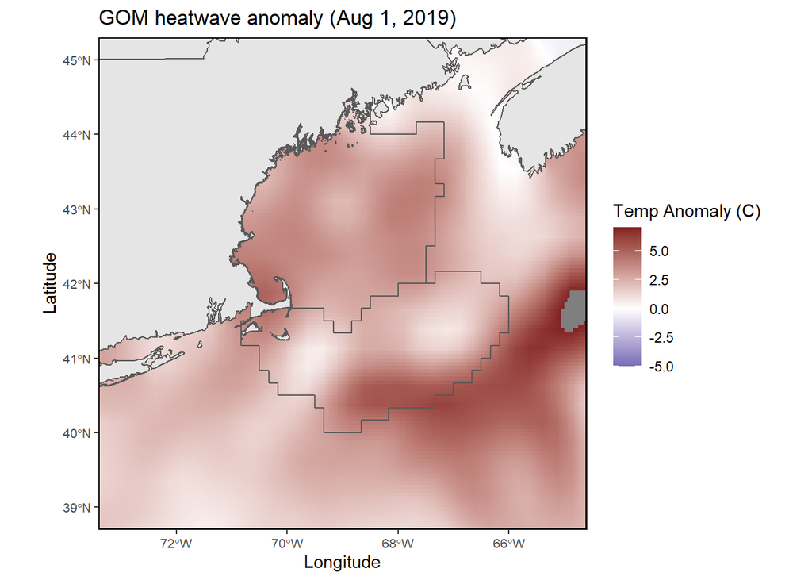

Maximum intensity heatwave anomaly in Gulf of Maine occuring on August 1, 2019.

[figure not shown]

## Shelfwide Indicators

### Seasonal SST anomaly

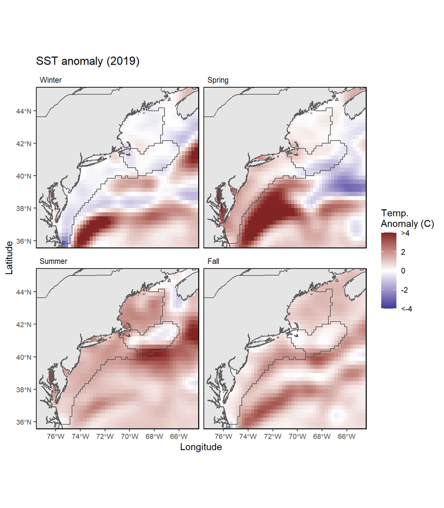

Seasonal sea surface temperature anomalies for 2019 over the Northeast US Shelf.

### Long-term SST

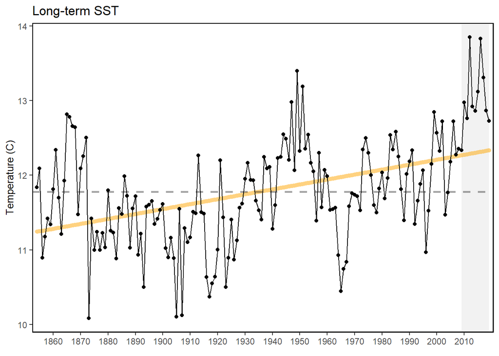

Average annual sea surface temperature (SST) over the Northeast US Shelf.